# Homework 2

For each of the problems below, the expectation is that you submit a standalone HTML file (any images should be embedded) back to GitHub. Please do just one problem per HTML file. The first person to accept the assignment below should form an easily identifiable group name (likely using the names of your group members). Others in the group *should also accept* the assignment, and then they can just join the existing group.

[Accept Assignment](https://classroom.github.com/a/62yt3xQU)

## Problem 1

This first problem focuses on determining the temperature of stars from spectra. Recall that you generally have several ways of going about this, including both Wien’s law and Planck’s law. In the repository, in the `data` folder, are the spectra of 3 different stars, named `star1.csv`, `star2.csv`, and `star3.csv`. Your task is to determine the surface temperature of each star, in degrees kelvin, using both methods where possible. Describe how you went about doing so and provide graphical evidence of your work in your essay. For each star, compare the temperatures you got from each method and comment on which you’d trust more. If one of the methods was not possible, explain why.

## Problem 2

Here you will focus on determining the radial velocity of some unknown star. In the `data` folder in the repository is a file called `speedstar.csv`. Your task is to determine the exact location of at least 5 spectral peaks and to plot the rest wavelengths vs the observed wavelengths. You can fit a line to this data and compare to the known Doppler relation to determine the speed of the star with respect to Earth. To help with identifying common spectral lines and their rest wavelengths, I’m including the table below, where the shown wavelength is that transition’s *rest* wavelength:

| Wavelength (nm) | Element |
| --- | --- |
| 410.175 | $H_\delta$ |
| 434.047 | $H_\gamma$ |
| 438.355 | Fe |
| 486.270 | $H_\beta$ |
| 518.362 | Mg |
| 527.039 | Fe |
| 588.995 | Na |
| 589.592 | Na |
| 656.464 | $H_\alpha$ |
| 759.370 | $O_2$ |
| 849.8 | Ca II |
| 854.2 | Ca II |
| 866.2 | Ca II |

**Warning**

Students often want to apply the Doppler relation to individual peaks, getting a speed for each. **Do not do this!** It is highly sensitive to noise. Instead, make the plot of rest wavelengths vs observed wavelengths (which should have 5 points on it, one for each measured peak), and then fit a line to it. You can then get the speed by relating the Doppler relation to the slope of the line.

## Problem 3

The `gaia.zip` file in the `data` folder contains a CSV which contains magnitude and parallax (in milliarcseconds) information for stars within 200pc of Earth as measured by the Gaia mission. The Gaia mission uses 3 main filters for taking images: a G band, a B band, and an R band. The official image below showcases the range of wavelengths each of those bands is sensitive to:

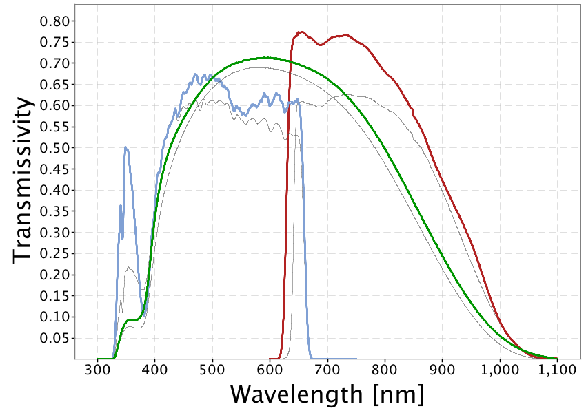

Spectral sensitivity of Gaia’s three main bands. Note that the G band covers the greatest range of wavelengths, largely accounting for both the R and B band regions.

The prime thing to keep in mind is that the G band is the most representative, covering mostly the sum of the B and R bands. Information about color though can be gotten from taking the difference between the B and R bands (in essence, asking the question: “Is this star more blue or more red?”).

Your task here is to make an HR diagram using the approximately 1.3 million stars in this dataset. Some things to keep in mind as you set about doing so:

- The observer’s model of an HR diagram will be more straightforward here, since everything is reported in magnitude values. So you’ll want the difference between the B and R magnitudes on the horizontal scale, and the *absolute* magnitude in the G band on the vertical scale
- Computing absolute magnitude requires a distance, which you can compute from the provided parallax angle (remembering that the provided values of parallax are in units of *milli*-arcseconds.
- HR diagrams always have brighter stars near the top, which means *smaller* absolute magnitudes. Thus, you will want to invert the y-axis (you can leave the x-axis unchanged if you did B - R for your difference: bluer stars will appear to the left, which is also where higher temperatures would be, as we’d expect from an HR diagram)
- Making a scatter plot of 1.3 million data points is going to leave a messy blob in areas of concentrated stars. A better method of visualizing these dense regions on the diagram is to explore other options, perhaps using 2d histograms, KDE plots, or similar. And you can always use both: layering, for instance, a 2d histogram on top of the scatter plot, so that you get the benefits of both.
- You are plotting a lot of points here. Be patient with your computer as it works though things. It will likely take longer than normal. I might suggest testing different plotting options or styles with a reduced sample of the dataset to speed up testing, and then run it with the full dataset once you are happy with everything.

Looking at your final diagram, **are all the parts of an HR diagram that you would normally expect visible?** Or, by only looking at stars within 200 pc, have we lost parts of the diagram?

## Problem 4

In this problem, you will be working with two datasets, each of which contains stars located within a certain angular distance of the center of a star cluster. The CSV for the first cluster is `star_cluster1.csv` and for the second cluster `star_cluster2.csv`. Both are again taken from the Gaia mission, and report the same 4 columns as in Problem 3 above. Your task in this problem is relatively straightforward to describe: determine which of the two clusters is older.

Something to be aware of when looking at the datasets is that they represent *all* the stars within a small *angular* distance of the center of the cluster in the night sky. As such, they also contain stars that might be in front of the star cluster in question, or behind it and shining through. A vital step is therefore going to be filtering down the collection of stars to contain *only those actually within the star cluster in question*. How will you know what to filter? Both angular distances used to gather the stars were fairly small, so stars that are members of the cluster should represent the bulk of stars in the collection. And stars that are part of a cluster will not only be nearby in the night sky, but will also be similar *distances away from us here on Earth*. So you can look at the distribution of stellar distances in each dataset to determine the dominant distance, and then filter to only keep those stars.

Ensure that your computational essay provides evidence for how you came up with which cluster is older, and includes visuals as appropriate or useful.